# Tipología y ciclo de vida de los datos

# ¿Cómo realizar la limpieza y análisis de datos?

Autores: Eduardo Mora González y Diego Sánchez De La Fuente

Enero 2023

Instalamos y cargamos las librerías necesarias.

```r
if (!require('readr')) install.packages('readr');
library('readr')
if (!require('ggplot2')) install.packages('ggplot2');
library('ggplot2')
if (!require('DataExplorer')) install.packages('DataExplorer');
library('DataExplorer')
if (!require('corrplot')) install.packages("corrplot");
library(corrplot)
if (!require('factoextra')) install.packages("factoextra");
library(factoextra)
if (!require('dplyr')) install.packages("dplyr");
library(dplyr)
if (!require('DescTools')) install.packages("DescTools");
library(DescTools)
if (!require('regclass')) install.packages("regclass");
library(regclass)
if(!require('randomForest'))
{
  install.packages('randomForest',repos='http://cran.us.r-project.org');
}
library(randomForest)
if(!require('iml'))
{
  install.packages('iml', repos='http://cran.us.r-project.org');
}
library(iml)
if(!require("tidyverse"))install.packages("DeskTools");
library("tidyverse")
if(!require("rpart")) install.packages("rpart");library("rpart")
if(!require("rpart.plot")) install.packages("rpart.plot");
library("rpart.plot")
if(!require("caret"))install.packages("caret");
library("caret")
if(!require('patchwork'))
{
  install.packages('patchwork',repos='http://cran.us.r-project.org');
}
library(patchwork)
```

# 1 Dataset

## 1.1 Motivación

En Europa, el paro cardiaco es una de las primeras causas de mortalidad y en España fallecen en torno a 100 personas al día por este suceso [https://fundaciondelcorazon.com/prensa/notas-de-prensa/2900-solo-el-30-de-espanoles-sabe-realizar-la-reanimacion-cardio-pulmonar-rcp-.html], esto representa aproximadamente el 31% de las muertes a nivel mundial.

## 1.2 Descripción del dataset

El conjunto de datos ha sido extraido de Kaggle: https://www.kaggle.com/datasets/rashikrahmanpritom/heart-attack-analysis-prediction-dataset, está compuesto de 12 variables y 918 registros. Que correlacionan una serie de caracteristicas recogidas de varios pacientes con la posibilidad de sufrir un ataque al corazón.

## 1.3 Carga del fichero de datos

```r
datos <- read_csv("./fichero_original_datos.csv")
attach(datos)
```

## 1.4 Tipos de datos

```r
# Cargamos en un vector los tipos de variable del datase
vector_tipos <- sapply(datos, function(x) class(x))
print(vector_tipos)
```

```
##            Age            Sex  ChestPainType      RestingBP    Cholesterol
##      "numeric"    "character"    "character"      "numeric"      "numeric"
##      FastingBS     RestingECG          MaxHR ExerciseAngina        Oldpeak
##      "numeric"    "character"      "numeric"    "character"      "numeric"
##       ST_Slope   HeartDisease
##    "character"      "numeric"
```

Ahora vamos a ver las estructura del juego de datos

```r
str(datos)
```

```
## spec_tbl_df [918 × 12] (S3: spec_tbl_df/tbl_df/tbl/data.frame)
##  $ Age           : num [1:918] 40 49 37 48 54 39 45 54 37 48 ...
##  $ Sex           : chr [1:918] "M" "F" "M" "F" ...
##  $ ChestPainType : chr [1:918] "ATA" "NAP" "ATA" "ASY" ...
##  $ RestingBP     : num [1:918] 140 160 130 138 150 120 130 110 140 120 ...
##  $ Cholesterol   : num [1:918] 289 180 283 214 195 339 237 208 207 284 ...
##  $ FastingBS     : num [1:918] 0 0 0 0 0 0 0 0 0 0 ...
##  $ RestingECG    : chr [1:918] "Normal" "Normal" "ST" "Normal" ...
##  $ MaxHR         : num [1:918] 172 156 98 108 122 170 170 142 130 120 ...
##  $ ExerciseAngina: chr [1:918] "N" "N" "N" "Y" ...
##  $ Oldpeak       : num [1:918] 0 1 0 1.5 0 0 0 0 1.5 0 ...
##  $ ST_Slope      : chr [1:918] "Up" "Flat" "Up" "Flat" ...
##  $ HeartDisease  : num [1:918] 0 1 0 1 0 0 0 0 1 0 ...
##  - attr(*, "spec")=
##   .. cols(
##   ..   Age = col_double(),
##   ..   Sex = col_character(),
##   ..   ChestPainType = col_character(),
##   ..   RestingBP = col_double(),
##   ..   Cholesterol = col_double(),
##   ..   FastingBS = col_double(),
##   ..   RestingECG = col_character(),
##   ..   MaxHR = col_double(),
##   ..   ExerciseAngina = col_character(),
##   ..   Oldpeak = col_double(),
##   ..   ST_Slope = col_character(),
##   ..   HeartDisease = col_double()
##   .. )
##  - attr(*, "problems")=<externalptr>
```

Vamos ahora a sacar estadísticas básicas

```r
summary(datos)
```

```
##       Age            Sex            ChestPainType        RestingBP
##  Min.   :28.00   Length:918         Length:918         Min.   :  0.0
##  1st Qu.:47.00   Class :character   Class :character   1st Qu.:120.0
##  Median :54.00   Mode  :character   Mode  :character   Median :130.0
##  Mean   :53.51                                         Mean   :132.4
##  3rd Qu.:60.00                                         3rd Qu.:140.0
##  Max.   :77.00                                         Max.   :200.0
##   Cholesterol      FastingBS       RestingECG            MaxHR
##  Min.   :  0.0   Min.   :0.0000   Length:918         Min.   : 60.0
##  1st Qu.:173.2   1st Qu.:0.0000   Class :character   1st Qu.:120.0
##  Median :223.0   Median :0.0000   Mode  :character   Median :138.0
##  Mean   :198.8   Mean   :0.2331                      Mean   :136.8
##  3rd Qu.:267.0   3rd Qu.:0.0000                      3rd Qu.:156.0
##  Max.   :603.0   Max.   :1.0000                      Max.   :202.0
##  ExerciseAngina        Oldpeak          ST_Slope          HeartDisease
##  Length:918         Min.   :-2.6000   Length:918         Min.   :0.0000
##  Class :character   1st Qu.: 0.0000   Class :character   1st Qu.:0.0000
##  Mode  :character   Median : 0.6000   Mode  :character   Median :1.0000
##                     Mean   : 0.8874                      Mean   :0.5534
##                     3rd Qu.: 1.5000                      3rd Qu.:1.0000
##                     Max.   : 6.2000                      Max.   :1.0000
```

Observamos los primeros 5 registros:

```r
head(datos, 5L)
```

```
## # A tibble: 5 × 12
##     Age Sex   ChestPainT…¹ Resti…² Chole…³ Fasti…⁴ Resti…⁵ MaxHR Exerc…⁶ Oldpeak
##   <dbl> <chr> <chr>          <dbl>   <dbl>   <dbl> <chr>   <dbl> <chr>     <dbl>
## 1    40 M     ATA              140     289       0 Normal    172 N           0
## 2    49 F     NAP              160     180       0 Normal    156 N           1
## 3    37 M     ATA              130     283       0 ST         98 N           0
## 4    48 F     ASY              138     214       0 Normal    108 Y           1.5
## 5    54 M     NAP              150     195       0 Normal    122 N           0
## # … with 2 more variables: ST_Slope <chr>, HeartDisease <dbl>, and abbreviated
## #   variable names ¹ChestPainType, ²RestingBP, ³Cholesterol, ⁴FastingBS,
## #   ⁵RestingECG, ⁶ExerciseAngina
```

## 1.5 Objetivo buscado

Se puede decir que el objetivo buscado es predecir la posibilidad de que una persona tenga un alto riesgo de ser diagnosticado como un paciente cardíaco a través de las diversas características. Para llegar a al objetivo se tiene pensado realizar diversos métodos de análisis para así relacionar las diversas características para obtener unos parámetros finales y así concluir la posibilidad de que una persona tenga o no una enfermedad cardiaca.

# 2 Preprocesado, gestión de características y exploración de los datos.

## 2.1 Valores nulos del conjunto de los datos

De tipo numérico

```r
colSums(is.na(datos))
```

```
##            Age            Sex  ChestPainType      RestingBP    Cholesterol
##              0              0              0              0              0
##      FastingBS     RestingECG          MaxHR ExerciseAngina        Oldpeak
##              0              0              0              0              0
##       ST_Slope   HeartDisease
##              0              0
```

De tipo cadena

```r
colSums(datos=="")
```

```
##            Age            Sex  ChestPainType      RestingBP    Cholesterol
##              0              0              0              0              0
##      FastingBS     RestingECG          MaxHR ExerciseAngina        Oldpeak
##              0              0              0              0              0
##       ST_Slope   HeartDisease
##              0              0
```

Como se puede comprobar, tenemos la “suerte” de no tener ningún valor nulo o vacío en los dos juegos de datos.

## 2.2 Normalización del conjunto de los datos

### 2.2.1 EDAD (Age)

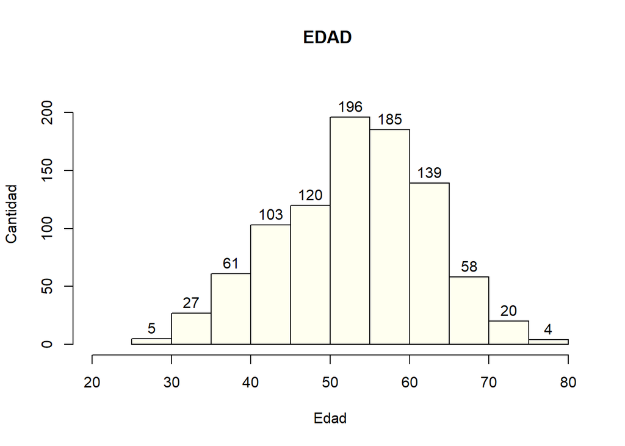

```r
#Histograma de la característica edad del primer conjunto de datos
h1 <- hist(datos$Age, xlab="Edad", col="ivory",
           ylab="Cantidad", main="EDAD ", ylim = c(0, 225), xlim = c(20,80))
text(h1$mids,h1$counts,labels=h1$counts, adj=c(0.5, -0.5))
```

Como se puede observar, la franja de entre los 50 y 60 años son donde más datos existen, mientras que los extremos donde menos datos.

### 2.2.2 SEXO (Sex)

Normalizamos para tenerlo de tipo numérico todas la variables

```r
#Cambiamos las letras por los números
datos$Sex [datos$Sex == "M"] <- 1
datos$Sex [datos$Sex == "F"] <- 0

#Pasamos de carácter a numérico
datos$Sex <- as.numeric(datos$Sex)
```

Una vez normalizada la característica , analizamos el conjunto de los datos contemplados en esta.

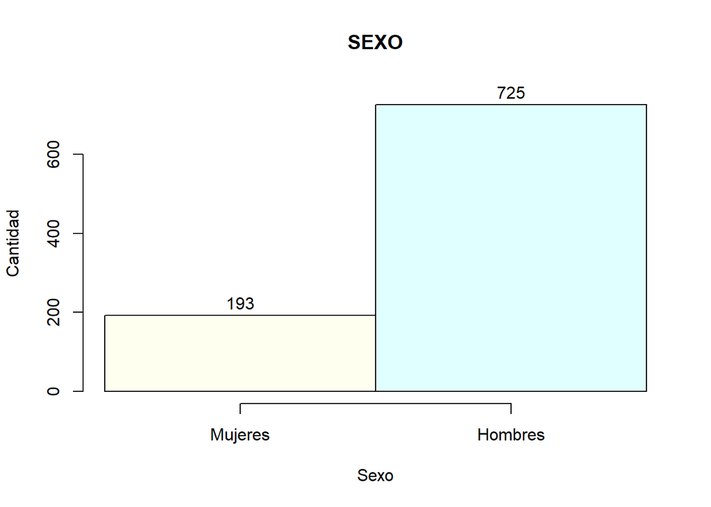

```r
h1 <- hist(datos$Sex, xlab="Sexo", col=c("ivory", "lightcyan"),
           ylab="Cantidad", main="SEXO", breaks = 2, ylim = c(0, 750), axes = FALSE)
text(h1$mids,h1$counts,labels=h1$counts, adj=c(0.5, -0.5))
axis(1, at =c(0.25, 0.75), cex.axis=1, labels = c("Mujeres","Hombres" ))
axis(2)
```

### 2.2.3 TIPO DE DOLOR TORÁCICO (ChestPainType)

Nos damos cuenta de que el conjunto de datos viene identificado por 4 variables categóricas (TA: angina típica, ATA: angina atípica, NAP: dolor no anginal, ASY: asintomático). Normalizamos para tenerlo de tipo numérico todas la variables:

```r
#Cambiamos las letras por los números
datos$ChestPainType [datos$ChestPainType == "TA"]  <- 0
datos$ChestPainType [datos$ChestPainType == "ATA"] <- 1
datos$ChestPainType [datos$ChestPainType == "NAP"] <- 2
datos$ChestPainType [datos$ChestPainType == "ASY"] <- 3

#Pasamos de carácter a numérico
datos$ChestPainType <- as.numeric(datos$ChestPainType)
```

Una vez normalizada la característica , analizamos el conjunto de los datos contemplados en esta.

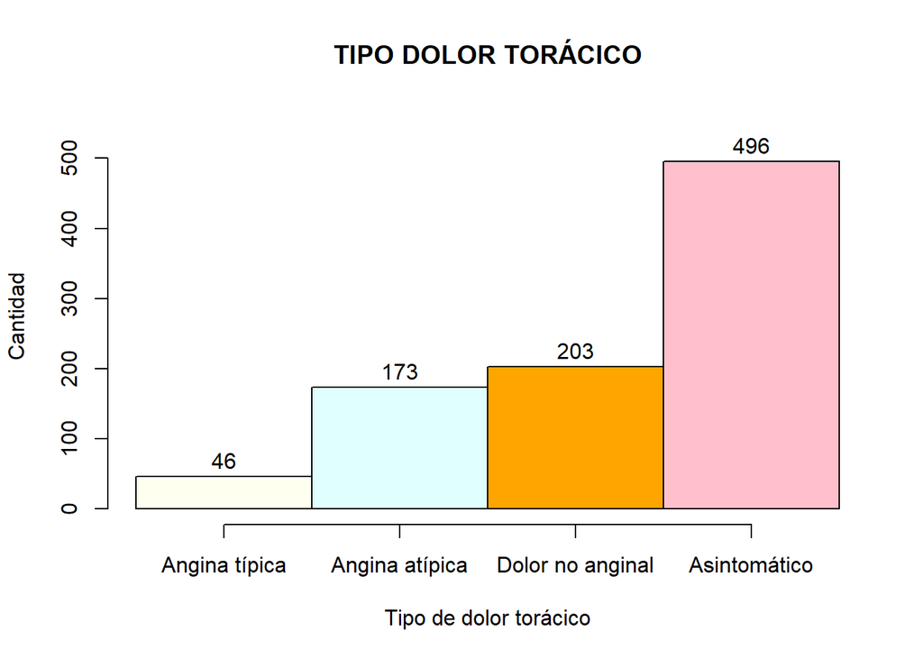

```r
h1 <- hist(datos$ChestPainType, xlab="Tipo de dolor torácico",
           col= c("ivory", "lightcyan", "ORANGE", "PINK"),
           ylab="Cantidad", main="TIPO DOLOR TORÁCICO",
           ylim = c(0, 550),axes = FALSE,
           breaks=seq(min(datos$ChestPainType)-0.5,
                      max(datos$ChestPainType)+0.5, by=1) )
text(h1$mids,h1$counts,labels=h1$counts, adj=c(0.5, -0.5))
axis(1, at =c(0,1,2,3), cex.axis=1,
     labels = c("Angina típica", "Angina atípica","Dolor no anginal", "Asintomático" ))
axis(2)
```

como se puede comprobar, tenemos mas casos de de asintomaticos que del resto.

### 2.2.4 PRESIÓN ARTERIAL EN REPOSO (RestingBP)

Como se muestran en las estadísticas esta característica es de tipo numérico y en el conjunto de datos va desde 0 hasta 200. Como se puede apreciar, tener una presión arterial de 0 es estar considerado muerto, por lo que considero que el valor 0 es un valor nulo.

Lo primero que se va a hacer es obtener el número de casos que la presión arterial es 0, y se consideraran las diversas formas de tratar estos datos:

```r
#Veces que aparece el valor cero en la presion arterial
length(datos$RestingBP[datos$RestingBP == 0])
```

```
## [1] 1
```

Como solo aparece una vez, se le asignará un valor por defecto. El valor por defecto será el más común.

```r
#Función para calcular el valor más común
common_value <- function(x) {
uniqx <- unique(na.omit(x))
uniqx[which.max(tabulate(match(x, uniqx)))]
}

#Calculamos el valor más comun
BP_comun <- common_value(datos$RestingBP)

#Asignamos el valor
datos$RestingBP[datos$RestingBP == 0] <- BP_comun

#vemos las estaditicas del dato
summary(datos$RestingBP)
```

```
##    Min. 1st Qu.  Median    Mean 3rd Qu.    Max.
##    80.0   120.0   130.0   132.5   140.0   200.0
```

Ahora ya tenemos los valores entre 80 y 200 que son un rango normal para estos valores.

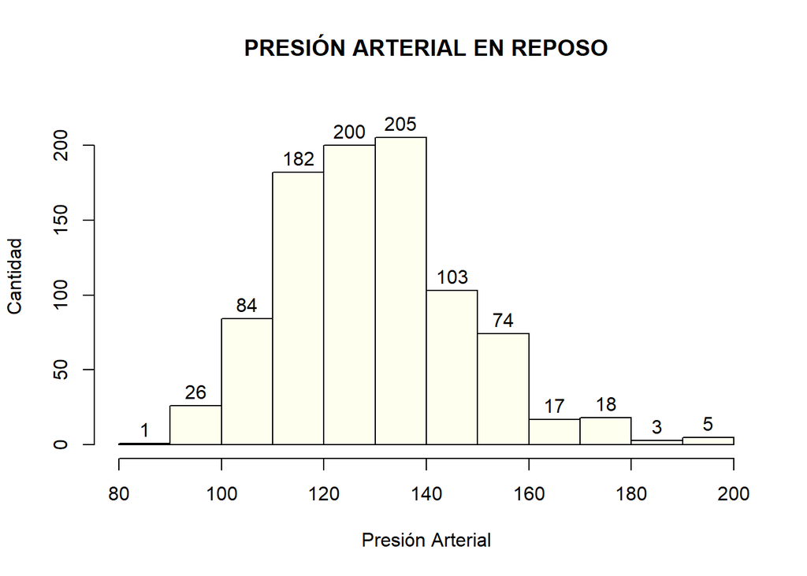

```r
#Histograma de la característica Presión Arterial del primer conjunto de datos
h1 <- hist(datos$RestingBP, xlab="Presión Arterial", col="ivory",
           ylab="Cantidad", main="PRESIÓN ARTERIAL EN REPOSO",
           ylim = c(0, 225), xlim = c(80,200))
text(h1$mids,h1$counts,labels=h1$counts, adj=c(0.5, -0.5))
```

### 2.2.5 COLESTEROL (Cholesterol)

La siguiente característica es de tipo numérico. Al igual que en la presión arterial en reposo, que tenemos valores 0 que debemos analizar. Lo primero que se va a hacer es obtener el numero de casos que el colesterol es 0, y se consideraran las diversas formas de tratar estos datos.

```r
#Veces que aparece el valor cero en la presion arterial
length(datos$RestingBP[datos$Cholesterol == 0])
```

```
## [1] 172
```

Esta vez tenemos 172 casos en lo que ocurre esto (equivale a un 18% de los casos totales). Antes de ver que valor se le asignan, se va a graficar los datos para ver de manera grafica que opción tomar: el valor medio o el más común.

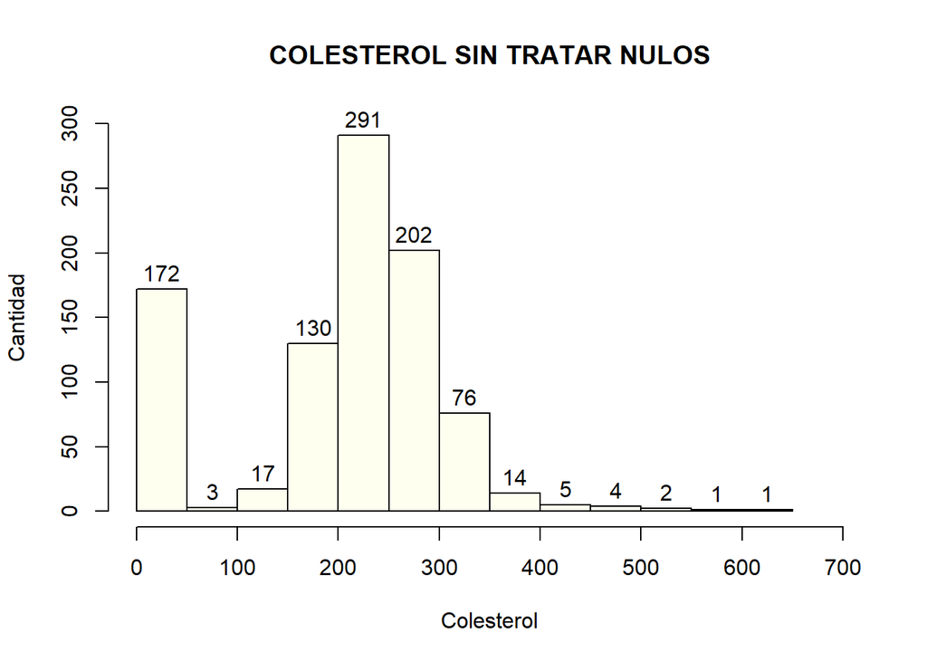

```r
h1 <- hist(datos$Cholesterol, xlab="Colesterol", col="ivory",
           ylab="Cantidad", main="COLESTEROL SIN TRATAR NULOS", ylim = c(0,300),
           xlim = c(0, 700))
text(h1$mids,h1$counts,labels=h1$counts, adj=c(0.5, -0.5))
```

Tras analizar la gráfica y para no perder estos datos, se le asignaran un valor por defecto, que será la media de los datos. Esta decisión se ha tomado ya que poner el más común, nos crearía un conjunto de datos muy distintos entre unas medidas y otras, mientras que poner la media sería un valor que tenga en cuenta el grueso de todos los datos.

```r
#Calculamos el valor más comun
colesterol_media <- mean(datos$Cholesterol)

#Asignamos el valor truncado para evitar decimales
datos$Cholesterol[datos$Cholesterol == 0] <- trunc(colesterol_media)

#vemos las estaditicas del dato
summary(datos$RestingBP)
```

```
##    Min. 1st Qu.  Median    Mean 3rd Qu.    Max.
##    80.0   120.0   130.0   132.5   140.0   200.0
```

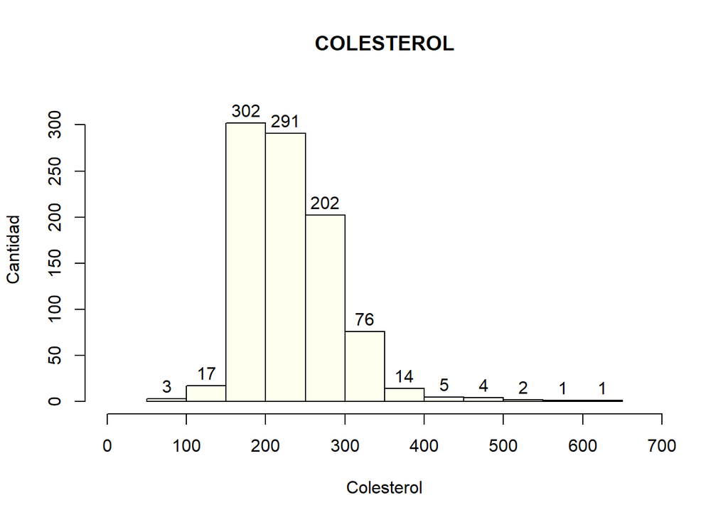

```r
h1 <- hist(datos$Cholesterol, xlab="Colesterol", col="ivory",
           ylab="Cantidad", main="COLESTEROL", ylim = c(0,330), xlim = c(0, 700))
text(h1$mids,h1$counts,labels=h1$counts, adj=c(0.5, -0.5))
```

### 2.2.6 NIVEL DE AZÚCAR EN SANGRE EN AYUNAS (FastingBS)

Como se puede comprobar el conjunto de los datos puedes ser 1 o 0, es decir verdadero o falso si se cumple la siguiente condición: si nivel de azúcar en sangre en ayunas> 120 mg / dl.

En esta característica no tenemos valores nulos, así que vamos a ver la distribución de las dos opciones:

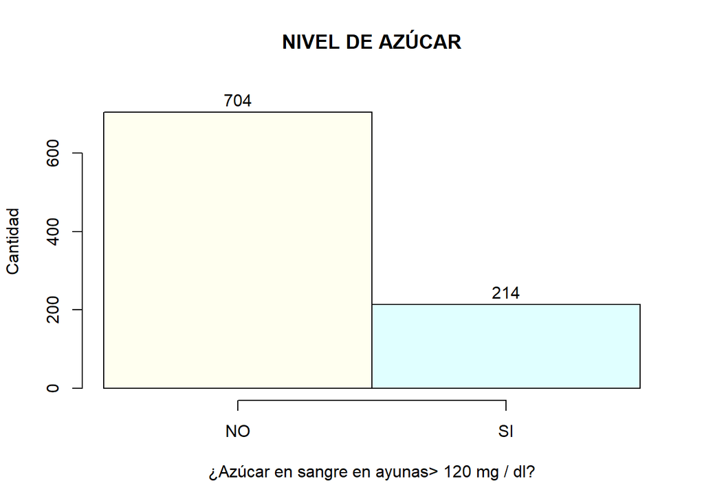

```r
h1 <- hist(datos$FastingBS, xlab="¿Azúcar en sangre en ayunas> 120 mg / dl?",
           col=c("ivory", "lightcyan"), ylab="Cantidad",
           main="NIVEL DE AZÚCAR", breaks = 2, ylim = c(0, 750), axes = FALSE)
text(h1$mids,h1$counts,labels=h1$counts, adj=c(0.5, -0.5))
axis(1, at =c(0.25, 0.75), cex.axis=1, labels = c("NO","SI" ))
axis(2)
```

Como se puede comprobar que hay mas casos que NO se cumple esa condición de que SÍ.

### 2.2.7 ECG EN REPOSO (RestingECG)

Nos damos cuenta de que el conjunto de datos viene identificado por 3 variables categóricas: + Normal: Normal, + ST: con anomalía de la onda ST-T + LVH: que muestra una hipertrofia ventricular izquierda probable o definitiva según los criterios de Estes. Normalizamos para tenerlo de tipo numérico todas la variables:

```r
#Cambiamos las letras por los números
datos$RestingECG [datos$RestingECG == "Normal"]  <- 0
datos$RestingECG [datos$RestingECG == "ST"] <- 1
datos$RestingECG [datos$RestingECG == "LVH"] <- 2

#Pasamos de carácter a numérico
datos$RestingECG <- as.numeric(datos$RestingECG)
```

Una vez normalizada la característica , analizamos el conjunto de los datos contemplados en esta.

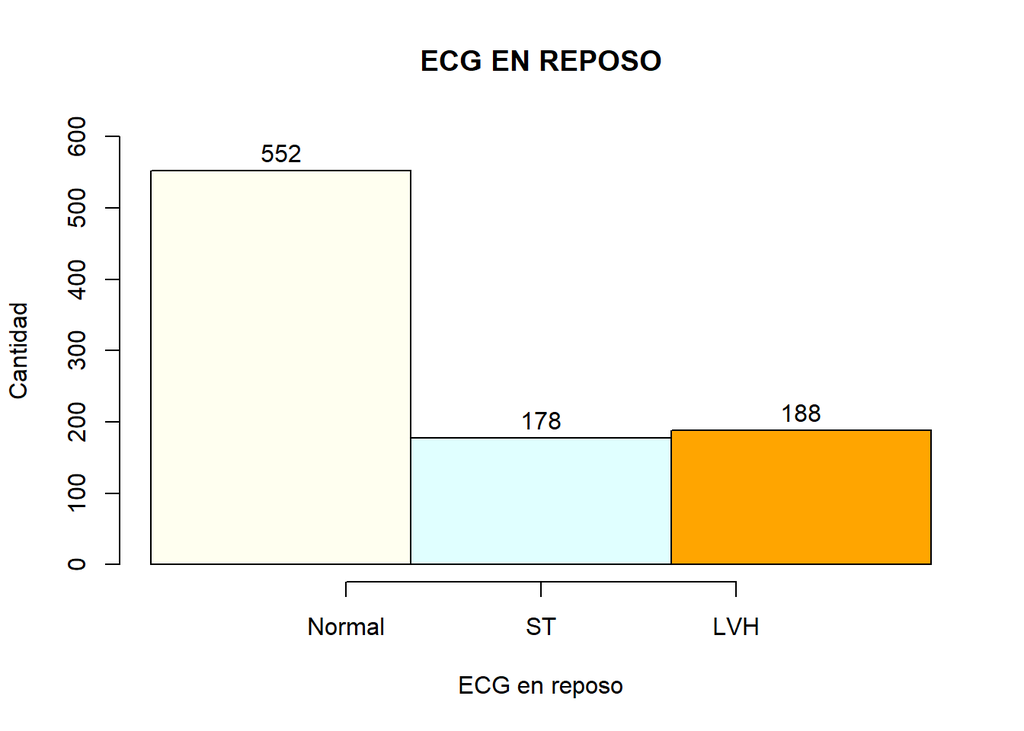

```r
h1 <- hist(datos$RestingECG, xlab="ECG en reposo",
           col= c("ivory", "lightcyan", "ORANGE"),
           ylab="Cantidad", main="ECG EN REPOSO",
           ylim = c(0, 600), axes = FALSE,
           breaks=seq(min(datos$RestingECG)-0.5,
                      max(datos$RestingECG)+0.5, by=1) )
text(h1$mids,h1$counts,labels=h1$counts, adj=c(0.5, -0.5))
axis(1, at =c(0.25, 1, 1.75 ), cex.axis=1, labels = c("Normal","ST", "LVH"))
axis(2)
```

### 2.2.8 FRECUENCIA CARDÍACA MÁXIMA (MaxHR)

Dicha característica es de carácter numérica y en el conjunto de datos contempla valores desde el 60 al 202

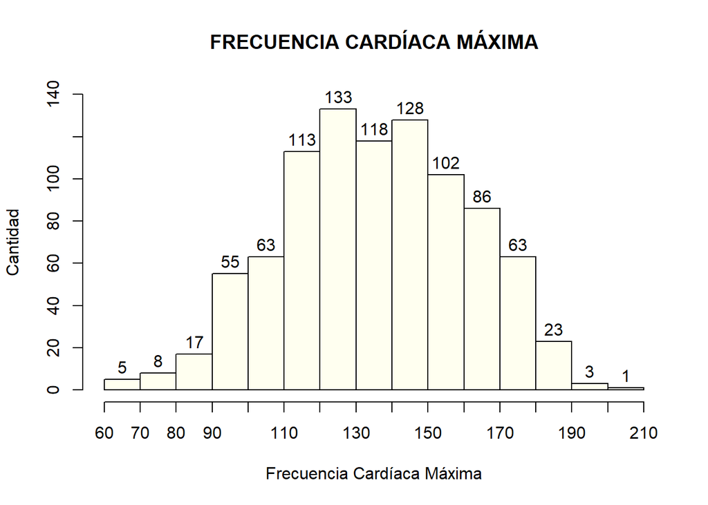

```r
h1 <- hist(datos$MaxHR, xlab="Frecuencia Cardíaca Máxima",
           col="ivory", ylab="Cantidad", main="FRECUENCIA CARDÍACA MÁXIMA",
           ylim = c(0,140), axes = FALSE)
text(h1$mids,h1$counts,labels=h1$counts, adj=c(0.5, -0.5))
axis(1, at =c(60, 70, 80,90,100,110,120,130,140,150,160,170,180,190,200,210), cex.axis=1)
axis(2)
```

Se puede comprobar que los extremos en el conjunto de datos tienen menos valores, y que el grueso de las muestras se encuentran entre los valores centrales (desde 100 a 180).

### 2.2.9 ANGINA INDUCIDA POR EJERCICIO (ExerciseAngina)

En el conjunto de datos tiene los valores Y: Sí, N: No. Al igual que se ha hecho con otras características, se normalizará el conjunto.

```r
#Cambiamos las letras por los números
datos$ExerciseAngina [datos$ExerciseAngina == "N"]  <- 0
datos$ExerciseAngina [datos$ExerciseAngina == "Y"]  <- 1

#Pasamos de carácter a numérico
datos$ExerciseAngina <- as.numeric(datos$ExerciseAngina)
```

Una vez normalizada la característica , analizamos el conjunto de los datos contemplados en esta.

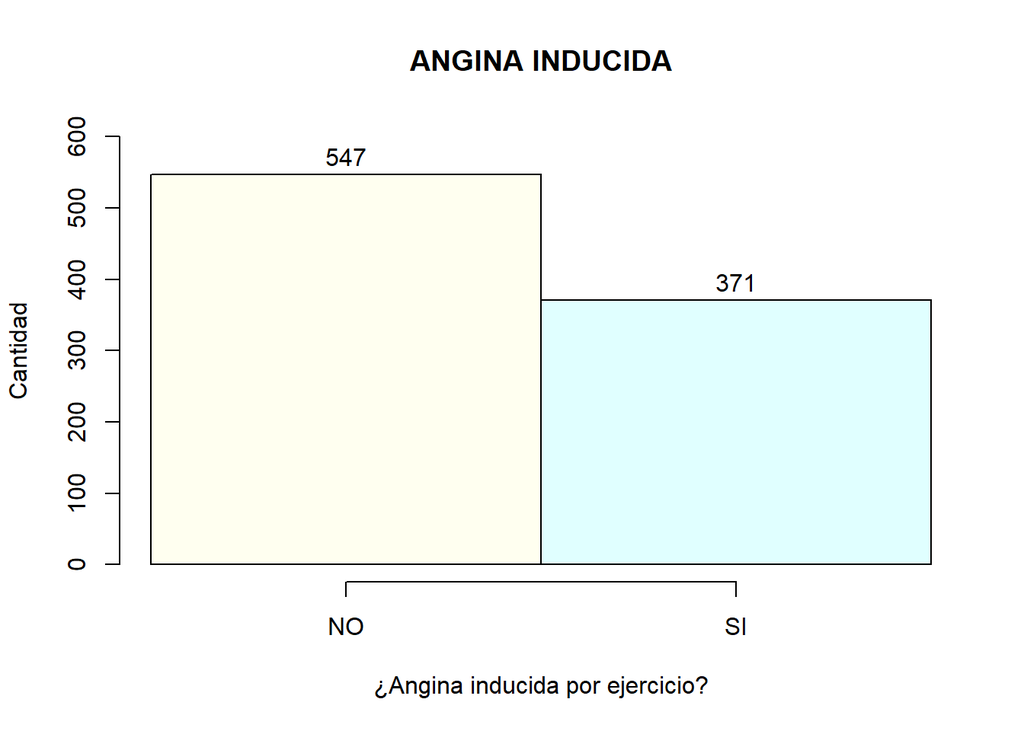

```r
h1 <- hist(datos$ExerciseAngina, xlab="¿Angina inducida por ejercicio?",
           col=c("ivory", "lightcyan"), ylab="Cantidad", main="ANGINA INDUCIDA",
           breaks = 2, ylim = c(0, 600), axes = FALSE)
text(h1$mids,h1$counts,labels=h1$counts, adj=c(0.5, -0.5))
axis(1, at =c(0.25, 0.75), cex.axis=1, labels = c("NO","SI" ))
axis(2)
```

Como se puede apreciar, hay mas casos en que NO se ha producido una angina inducida por el ejercicio de que Si se haya producido.

### 2.2.10 OLDPEAK

Esta característica de tipo numérica puede abarcar valores negativos hasta hasta un máximo de un valor igual a 6,2.

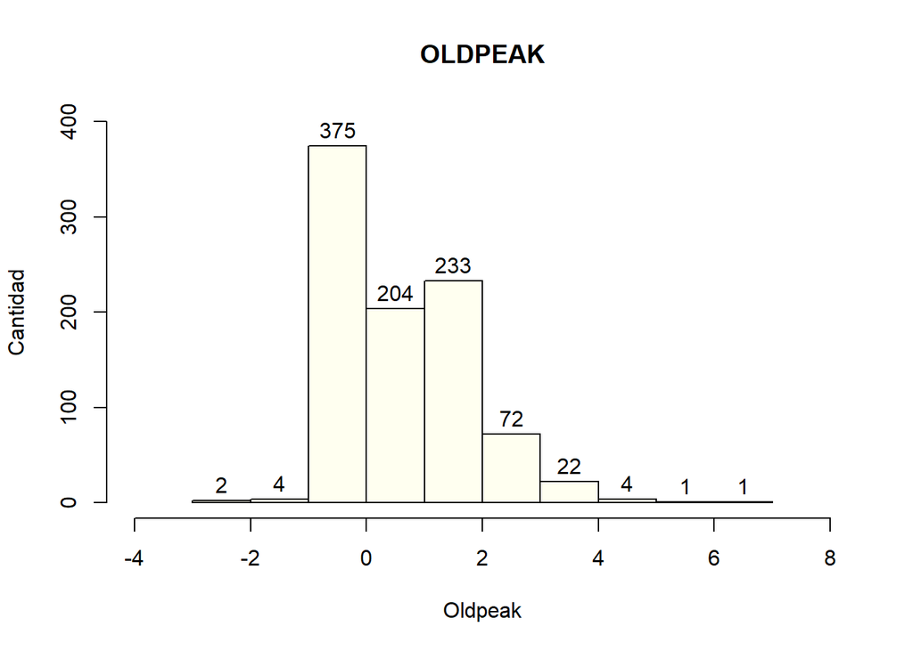

```r
h1 <- hist(datos$Oldpeak, xlab="Oldpeak", col="ivory", ylab="Cantidad", main="OLDPEAK", ylim = c(0,400), xlim = c(-4, 8))
text(h1$mids,h1$counts,labels=h1$counts, adj=c(0.5, -0.5))
```

### 2.2.11 PENDIENTE DEL SEGMENTO ST (ST_Slope)

Como ocurría en otras características anteriores el conjunto tiene los valores para esta caracteristica de la siguiente forma: + Up: uploping + Flat: flat + Down: downsloping Y como se ha realizado antes, se normalizará para solo tener datos numericos.

```r
#Cambiamos las letras por los números
datos$ST_Slope [datos$ST_Slope == "Up"]   <- 0
datos$ST_Slope [datos$ST_Slope == "Flat"] <- 1
datos$ST_Slope [datos$ST_Slope == "Down"] <- 2

#Pasamos de carácter a numérico
datos$ST_Slope <- as.numeric(datos$ST_Slope)
```

Una vez normalizada la característica , analizamos el conjunto de los datos contemplados en esta.

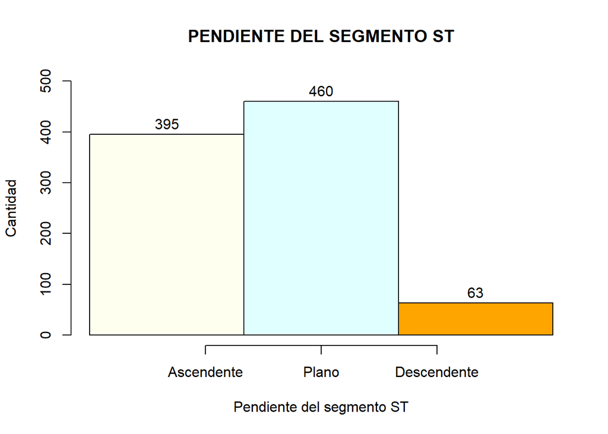

```r
h1 <- hist(datos$ST_Slope, xlab="Pendiente del segmento ST",
           col= c("ivory", "lightcyan", "ORANGE"), ylab="Cantidad",
           main="PENDIENTE DEL SEGMENTO ST", ylim = c(0, 500),
           axes = FALSE,breaks=seq(min(datos$ST_Slope)-0.5, max(datos$ST_Slope)+0.5, by=1) )
text(h1$mids,h1$counts,labels=h1$counts, adj=c(0.5, -0.5))
axis(1, at =c(0.25,1,1.75), cex.axis=1, labels = c("Ascendente","Plano", "Descendente"))
axis(2)
```

El caso más común es que la pendiente sea plana, teniendo menos casos en los casos descendentes.

### 2.2.12 ¿ENFERMEDAD CARDIACA? (HeartDisease)

En el conjunto de datos tienen normalizada la salida usando el valor 1: enfermedad cardíaca, y el valor 0: Normal.

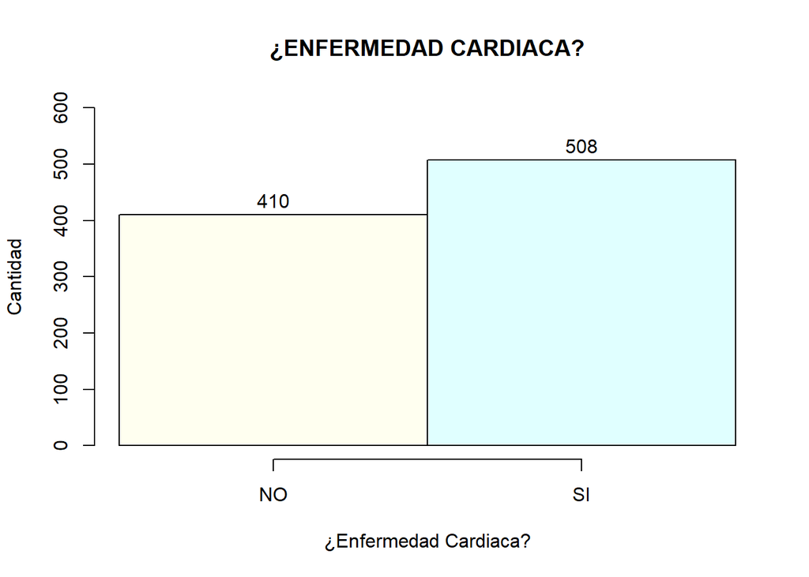

```r
h1 <- hist(datos$HeartDisease, xlab="¿Enfermedad Cardiaca?",
           col=c("ivory", "lightcyan"),
           ylab="Cantidad", main="¿ENFERMEDAD CARDIACA?",
           breaks = 2, ylim = c(0, 600), axes = FALSE)
text(h1$mids,h1$counts,labels=h1$counts, adj=c(0.5, -0.5))
axis(1, at =c(0.25, 0.75), cex.axis=1, labels = c("NO","SI" ))
axis(2)
```

Como se puede observar hay mas casos en que SI hay enfermedad cardiaca que caso en los que NO hay.

## 2.3 Construcción de conjunto de datos final

Renombramos las columnas para que tenga uno mas significativo y creamos el conjunto final de datos.

```r
datos_final <- datos

colnames(datos_final)[1]<-  "EDAD"
colnames(datos_final)[2]<-  "SEXO"
colnames(datos_final)[3]<-  "TIPO_DOLOR_TORAX"
colnames(datos_final)[4]<-  "PRESION_ARTERIAL"
colnames(datos_final)[5]<-  "COLESTEROL"
colnames(datos_final)[6]<-  "NIVEL_DE_AZUCAR"
colnames(datos_final)[7]<-  "ECG_EN_REPOSO"
colnames(datos_final)[8]<-  "FREC_CARDIACA_MAX"
colnames(datos_final)[9]<-  "ANGINA_x_EJERCICIO"
colnames(datos_final)[10]<- "OLDPEAK"
colnames(datos_final)[11]<- "PENDIENTE_ST"
colnames(datos_final)[12]<- "E_CARDIACA"
```

Por ultimo se va a mirar a través de los diagramas de cajas el rango de las características enfrentado a si un paciente tiene una enfermedad cardiaca o no.

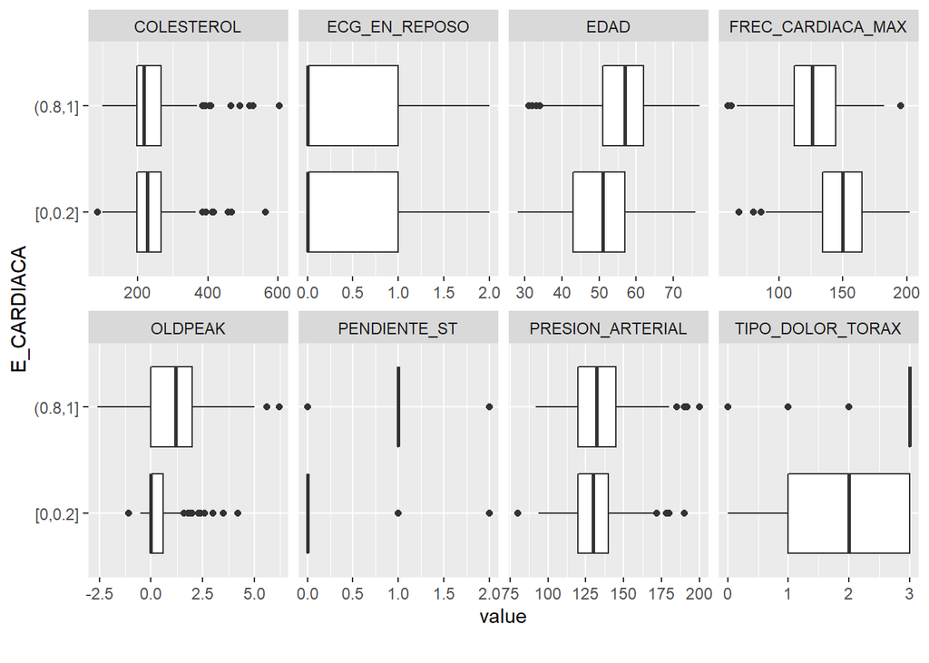

```r
#Diagrama de caja de todas las características enfrentadas a si un paciente tiene enfermedad cardiaca
plot_boxplot(datos_final, by = "E_CARDIACA")
```

## 2.4 Eliminamos outliers

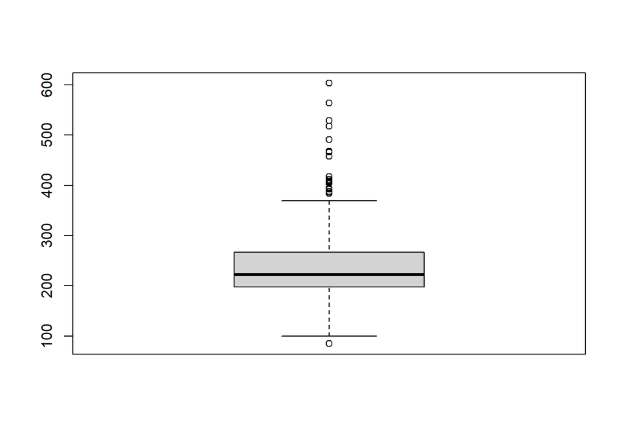

```r
datos_bp.colesterol <- boxplot(datos_final$COLESTEROL)
```

```r
datos_bp.colesterol.out <- datos_bp.colesterol$out
print("Eliminamos Outliers de la variable COLESTEROL con valores: ")
```

```
## [1] "Eliminamos Outliers de la variable COLESTEROL con valores: "
```

```r
datos_bp.colesterol.out
```

```
##  [1] 468 518 412 529  85 392 466 393 388 603 404 491 394 458 384 385 564 407 417
## [20] 409 394
```

```r
datos_final <- datos_final %>% filter(!(COLESTEROL %in% datos_bp.colesterol.out))
dev.off()
```

```r
datos_frec.cardiaca.max <- boxplot(datos_final$FREC_CARDIACA_MAX)
datos_frec.cardiaca.max.out <- datos_frec.cardiaca.max$out
print("Eliminamos Outliers de la variable FREC CARDIACA MAX con valores: ")
```

```
## [1] "Eliminamos Outliers de la variable FREC CARDIACA MAX con valores: "
```

```r
datos_frec.cardiaca.max.out
```

```
## [1] 63 60
```

```r
datos_final <- datos_final %>% filter(!(FREC_CARDIACA_MAX %in% datos_frec.cardiaca.max.out))
dev.off()
```

```r
datos_oldpeak <- boxplot(datos_final$OLDPEAK)
datos_oldpeak.out <- datos_oldpeak$out
print("Eliminamos Outliers de la variable OLDPEAK con valores: ")
```

```
## [1] "Eliminamos Outliers de la variable OLDPEAK con valores: "
```

```r
datos_oldpeak.out
```

```
##  [1]  4.0  5.0 -2.6  4.0  4.0  4.0  4.0  4.2  4.0  5.6  3.8  4.2  6.2  4.4  4.0
```

```r
datos_final <- datos_final %>% filter(!(OLDPEAK %in% datos_oldpeak.out))
dev.off()
```

```r
datos_bp.presion_arterial <- boxplot(datos_final$PRESION_ARTERIAL)
datos_bp.presion_arterial.out <- datos_bp.presion_arterial$out
print("Eliminamos Outliers de la variable PRESIÓN ARTERIAL ST con valores: ")
```

```
## [1] "Eliminamos Outliers de la variable PRESIÓN ARTERIAL ST con valores: "
```

```r
datos_bp.presion_arterial.out
```

```
##  [1] 190 180 180 200 180 180 180  80 200 185 200 180 180 178 172 180 190 174 180
## [20] 192 178 180 180 172
```

```r
datos_final <- datos_final %>% filter(!(PRESION_ARTERIAL %in% datos_bp.presion_arterial.out))
dev.off()
```

```r
datos_bp.tipo_dolor_torax <- boxplot(datos_final$TIPO_DOLOR_TORAX)
datos_bp.tipo_dolor_torax.out <- datos_bp.tipo_dolor_torax$out
print("Eliminamos Outliers de la variable TIPO DOLOR TORAX con valores: ")
```

```
## [1] "Eliminamos Outliers de la variable TIPO DOLOR TORAX con valores: "
```

```r
datos_bp.tipo_dolor_torax.out
```

```
##  [1] 0 0 0 0 0 0 0 0 0 0 0 0 0 0 0 0 0 0 0 0 0 0 0 0 0 0 0 0 0 0 0 0 0 0 0 0 0 0
## [39] 0 0 0 0 0 0
```

```r
datos_final <- datos_final %>% filter(!(TIPO_DOLOR_TORAX %in% datos_bp.tipo_dolor_torax.out))
dev.off()
```

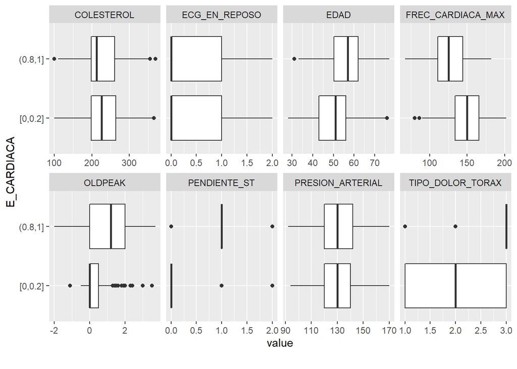

```r
#Diagrama de caja de todas las características enfrentadas a si un paciente tiene enfermedad cardiaca
plot_boxplot(datos_final, by = "E_CARDIACA")
```

## 2.5 Correlaciones

```r
#Calculamos las correlaciones
cor_datos <- cor(datos_final)
cor_datos
```

```
##                             EDAD        SEXO TIPO_DOLOR_TORAX PRESION_ARTERIAL
## EDAD                1.0000000000  0.07987476       0.23222966       0.26263094
## SEXO                0.0798747606  1.00000000       0.21446723       0.06480334
## TIPO_DOLOR_TORAX    0.2322296603  0.21446723       1.00000000       0.05761116
## PRESION_ARTERIAL    0.2626309425  0.06480334       0.05761116       1.00000000
## COLESTEROL         -0.0002226103 -0.13574432      -0.04056882       0.06464654
## NIVEL_DE_AZUCAR     0.1888535829  0.11982017       0.17113944       0.04940893
## ECG_EN_REPOSO       0.2045327265 -0.01651334       0.09834667       0.07584846
## FREC_CARDIACA_MAX  -0.4065414509 -0.19479093      -0.36601006      -0.11900267
## ANGINA_x_EJERCICIO  0.2232404235  0.20949172       0.42401538       0.17055230
## OLDPEAK             0.2647072227  0.13871819       0.32323764       0.18156990
## PENDIENTE_ST        0.2649516503  0.16347763       0.38922582       0.06577099
## E_CARDIACA          0.3112477185  0.31757032       0.55357954       0.11663793
##                       COLESTEROL NIVEL_DE_AZUCAR ECG_EN_REPOSO
## EDAD               -0.0002226103      0.18885358    0.20453273
## SEXO               -0.1357443154      0.11982017   -0.01651334
## TIPO_DOLOR_TORAX   -0.0405688154      0.17113944    0.09834667
## PRESION_ARTERIAL    0.0646465372      0.04940893    0.07584846
## COLESTEROL          1.0000000000     -0.11313552    0.10184968
## NIVEL_DE_AZUCAR    -0.1131355201      1.00000000    0.03428603
## ECG_EN_REPOSO       0.1018496822      0.03428603    1.00000000
## FREC_CARDIACA_MAX   0.1075182058     -0.14779921    0.01659835
## ANGINA_x_EJERCICIO  0.0643936183      0.07501356    0.05301848
## OLDPEAK             0.0471006517      0.08503826    0.11254750
## PENDIENTE_ST       -0.0493791928      0.17525733    0.06863116
## E_CARDIACA         -0.0477984682      0.28341365    0.08182717
##                    FREC_CARDIACA_MAX ANGINA_x_EJERCICIO     OLDPEAK
## EDAD                     -0.40654145         0.22324042  0.26470722
## SEXO                     -0.19479093         0.20949172  0.13871819
## TIPO_DOLOR_TORAX         -0.36601006         0.42401538  0.32323764
## PRESION_ARTERIAL         -0.11900267         0.17055230  0.18156990
## COLESTEROL                0.10751821         0.06439362  0.04710065
## NIVEL_DE_AZUCAR          -0.14779921         0.07501356  0.08503826
## ECG_EN_REPOSO             0.01659835         0.05301848  0.11254750
## FREC_CARDIACA_MAX         1.00000000        -0.39834669 -0.18975488
## ANGINA_x_EJERCICIO       -0.39834669         1.00000000  0.43365158
## OLDPEAK                  -0.18975488         0.43365158  1.00000000
## PENDIENTE_ST             -0.36930737         0.45642629  0.48875764
## E_CARDIACA               -0.42346641         0.51376813  0.43751373
##                    PENDIENTE_ST  E_CARDIACA
## EDAD                 0.26495165  0.31124772
## SEXO                 0.16347763  0.31757032
## TIPO_DOLOR_TORAX     0.38922582  0.55357954
## PRESION_ARTERIAL     0.06577099  0.11663793
## COLESTEROL          -0.04937919 -0.04779847
## NIVEL_DE_AZUCAR      0.17525733  0.28341365
## ECG_EN_REPOSO        0.06863116  0.08182717
## FREC_CARDIACA_MAX   -0.36930737 -0.42346641
## ANGINA_x_EJERCICIO   0.45642629  0.51376813
## OLDPEAK              0.48875764  0.43751373
## PENDIENTE_ST         1.00000000  0.58120599
## E_CARDIACA           0.58120599  1.00000000
```

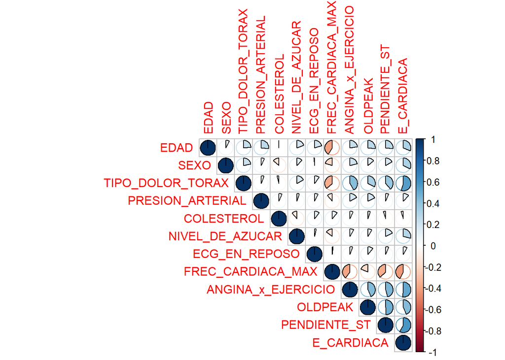

```r
#Representación de las correlaciones
corrplot(cor_datos, type="upper", method='pie')
```

## 2.6 Análisis de componentes principales (PCA)

Ahora se va a realizar un análisis de componentes sobre el conjunto de datos final. Lo primero que vamos a calcular es la varianza de todas las caracteristicas

```r
#Cálculo de la varianza de los componentes.
var <- apply(datos_final, 2, var)
var
```

```
##               EDAD               SEXO   TIPO_DOLOR_TORAX   PRESION_ARTERIAL
##         88.1377792          0.1621106          0.6374466        245.0442666
##         COLESTEROL    NIVEL_DE_AZUCAR      ECG_EN_REPOSO  FREC_CARDIACA_MAX
##       2160.3249895          0.1754691          0.6335349        637.4350996
## ANGINA_x_EJERCICIO            OLDPEAK       PENDIENTE_ST         E_CARDIACA
##          0.2422160          0.9478357          0.3549759          0.2478786
```

Como se puede observar de una manera bastante clara, el colesterol es la característica que mas varia de un individuo a otro.

Lo siguiente es centrar y escalar las características, para que así las variables pierdan esa variabilidad. Una vez calculada la matriz se la asigno al pca

```r
#Calculo de la descomposición de los componentes
pca <- prcomp(datos_final, scale = TRUE, center = TRUE)
pca
```

```
## Standard deviations (1, .., p=12):
##  [1] 1.8974493 1.1475086 1.0577031 0.9894707 0.9414635 0.9202567 0.8976197
##  [8] 0.8068512 0.7422484 0.6983699 0.6456073 0.5828417
##
## Rotation (n x k) = (12 x 12):
##                            PC1         PC2         PC3         PC4          PC5
## EDAD                0.28014843 -0.25245541  0.48732200 -0.07304964  0.256104929
## SEXO                0.20039780  0.33847469  0.03514677 -0.16476622 -0.763305970
## TIPO_DOLOR_TORAX    0.35837588  0.09136430 -0.13473172  0.16514131  0.005882123
## PRESION_ARTERIAL    0.13829428 -0.37958423  0.36362321 -0.59017736 -0.255760964
## COLESTEROL         -0.03058803 -0.57356528 -0.32677314  0.01280796 -0.005505378
## NIVEL_DE_AZUCAR     0.17188118  0.22329356  0.46905923  0.37182111  0.024273900
## ECG_EN_REPOSO       0.08311302 -0.46159376  0.23741130  0.58968414 -0.321590348
## FREC_CARDIACA_MAX  -0.33268947 -0.13119755 -0.16819561  0.23310113 -0.385916552
## ANGINA_x_EJERCICIO  0.37320411 -0.07541656 -0.29323460 -0.15482224  0.002822528
## OLDPEAK             0.33368710 -0.20542115 -0.24820847  0.01026826 -0.089164578
## PENDIENTE_ST        0.38478714  0.03185974 -0.20887652  0.12195037  0.151652559
## E_CARDIACA          0.43248195  0.10606714 -0.09073580  0.11184415 -0.048966672
##                            PC6         PC7         PC8         PC9         PC10
## EDAD               -0.19012829  0.07602767 -0.39586282  0.38465564  0.152868605
## SEXO               -0.11787912  0.27816619 -0.34470023  0.04446174 -0.013857771
## TIPO_DOLOR_TORAX   -0.10759466  0.20321763  0.60091060  0.54901398  0.003766156
## PRESION_ARTERIAL    0.22105853 -0.19709636  0.37321438 -0.07017404 -0.234844352
## COLESTEROL          0.33735336  0.62122599 -0.19252011  0.05017177 -0.123957417
## NIVEL_DE_AZUCAR     0.68485907  0.11737352  0.02332883 -0.16064936  0.172660255
## ECG_EN_REPOSO      -0.40796143 -0.05485229  0.10908375 -0.27682556 -0.025367300
## FREC_CARDIACA_MAX   0.31452613 -0.32365282  0.06117644  0.29035242  0.035570020
## ANGINA_x_EJERCICIO -0.01691429  0.05956734  0.17454230 -0.48906281  0.549950590
## OLDPEAK             0.16611307 -0.49474050 -0.28538178  0.26579163  0.355664752
## PENDIENTE_ST        0.07037292 -0.27927242 -0.23036132 -0.20690027 -0.608826995
## E_CARDIACA          0.09209677  0.05414122  0.07660088  0.04271721 -0.273082385
##                           PC11        PC12
## EDAD               -0.41570328 -0.08124084
## SEXO                0.02697977 -0.14584048
## TIPO_DOLOR_TORAX    0.08643164 -0.30804525
## PRESION_ARTERIAL    0.05681729 -0.02320323
## COLESTEROL          0.08777809 -0.02704705
## NIVEL_DE_AZUCAR     0.10225997 -0.11095277
## ECG_EN_REPOSO       0.11546071  0.02374709
## FREC_CARDIACA_MAX  -0.58343555 -0.08461831
## ANGINA_x_EJERCICIO -0.38969530 -0.13144093
## OLDPEAK             0.46313399  0.10654434
## PENDIENTE_ST       -0.12372310 -0.45235695
## E_CARDIACA         -0.24942136  0.78909996
```

Se puede ver que la primera componente tiene la mayor desviación estándar de todos los componentes. Para verlo de una manera mas clara, se va a representar de una manera grafica la salida anterior

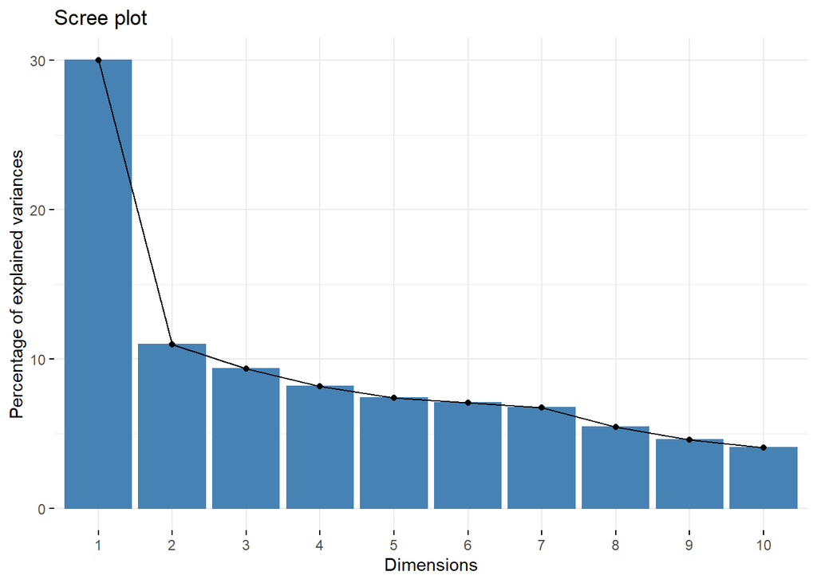

```r
#Representación PCA´s anteriores
fviz_eig(pca)
```

Como se ha visto antes, tanto de una manera numérica como gráfica, el PC1 es el que mejor de todos con una diferencia notable. Si usamos la técnica del codo, deberíamos coger solamente las dos primeras componentes.

Para confirmar la interpretación, no estaría de más obtener las estadísticas de todas las componentes

```r
#Estadísticas de las componentes
summary(pca)
```

```
## Importance of components:
##                          PC1    PC2     PC3     PC4     PC5     PC6     PC7
## Standard deviation     1.897 1.1475 1.05770 0.98947 0.94146 0.92026 0.89762
## Proportion of Variance 0.300 0.1097 0.09323 0.08159 0.07386 0.07057 0.06714
## Cumulative Proportion  0.300 0.4098 0.50299 0.58457 0.65844 0.72901 0.79615
##                            PC8     PC9    PC10    PC11    PC12
## Standard deviation     0.80685 0.74225 0.69837 0.64561 0.58284
## Proportion of Variance 0.05425 0.04591 0.04064 0.03473 0.02831
## Cumulative Proportion  0.85040 0.89631 0.93696 0.97169 1.00000
```

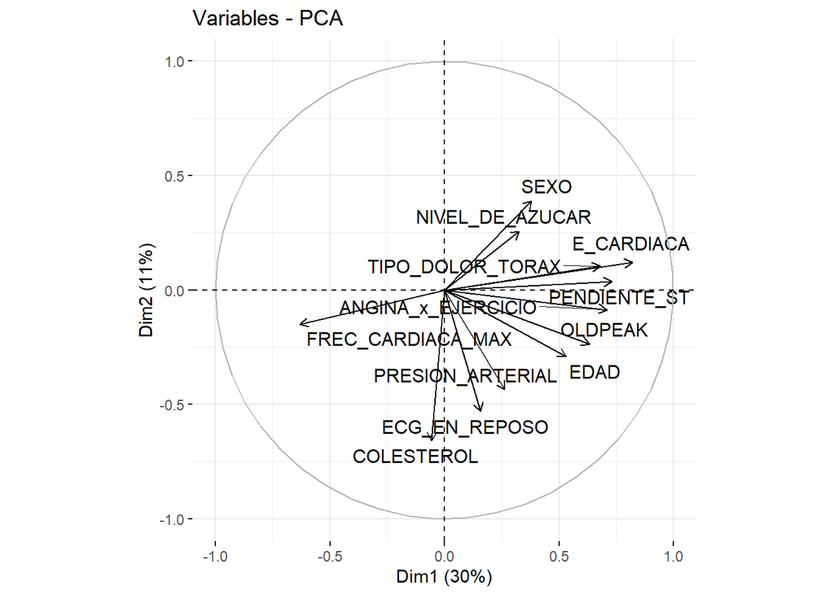

```r
#Representación de variables sobre componentes principales
fviz_pca_var(pca, repel = TRUE, scale = 0)
```

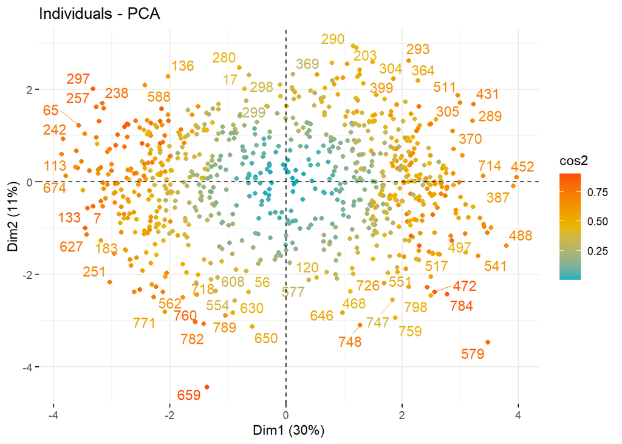

```r
#Representación de observaciones sobre componentes principales
fviz_pca_ind(pca, col.ind = "cos2", gradient.cols = c("#00AFBB", "#E7B800", "#FC4E07"), repel = TRUE)
```

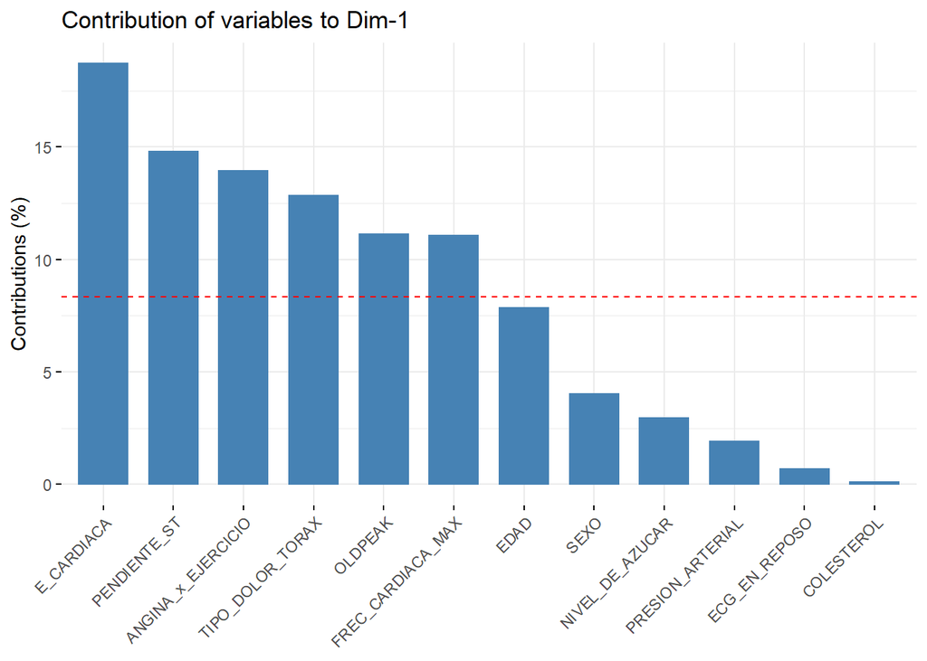

```r
#Representa la contribución de filas/columnas de los resultados de un pca
fviz_contrib(pca,choice = "var")
```

Una vez que hemos representada las variables y los individuos, se va a fusionar estas dos gráficas

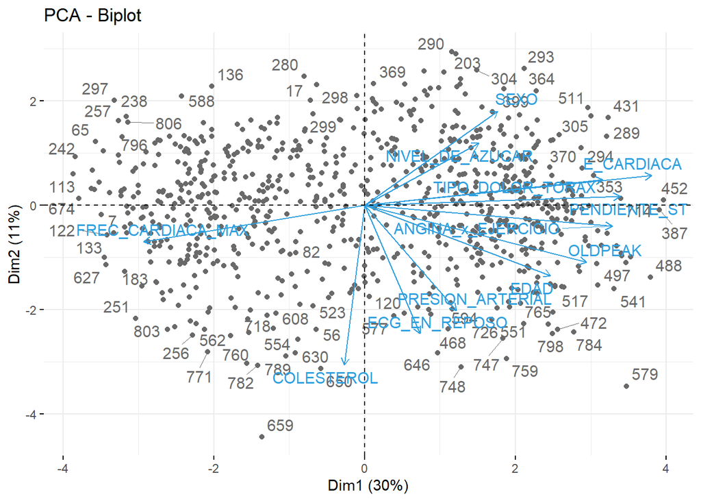

```r
#Representación de variables y los individuos en la misma gráfica
fviz_pca_biplot(pca, repel = TRUE, col.var = "#2E9FDF", col.ind = "#696969")
```

Aunque la opción de repelerse esta activada al ser bastantes casos no se puede ver una manera correcta, así que se a mostrar solamente los 10, 50 y 100 casos más influyentes

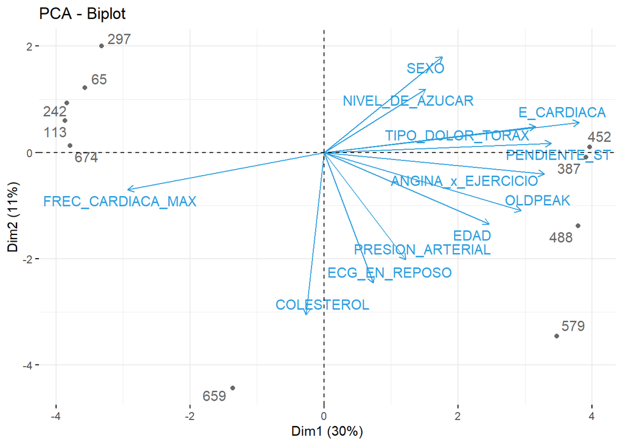

```r
#Representación de variables y los 10 individuos más influyentes en la misma gráfica
fviz_pca_biplot(pca, repel = TRUE, col.var = "#2E9FDF",
                col.ind = "#696969", select.ind = list(contrib = 10))
```

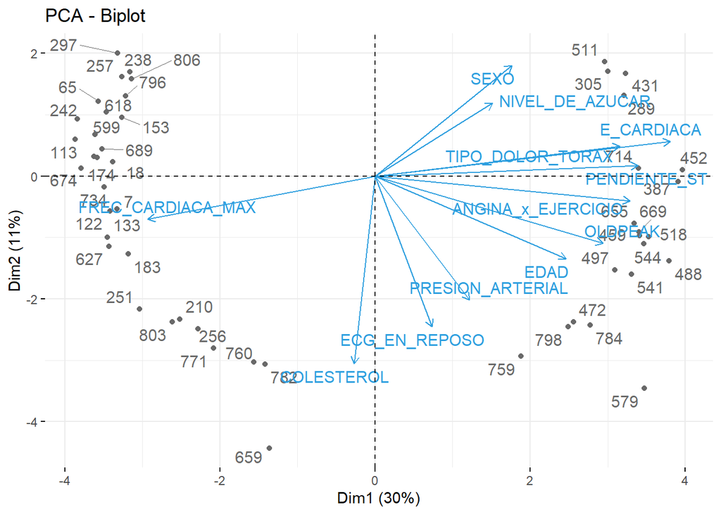

```r
#Representación de variables y los 50 individuos más influyentes en la misma gráfica
fviz_pca_biplot(pca, repel = TRUE, col.var = "#2E9FDF",
                col.ind = "#696969", select.ind = list(contrib = 50))
```

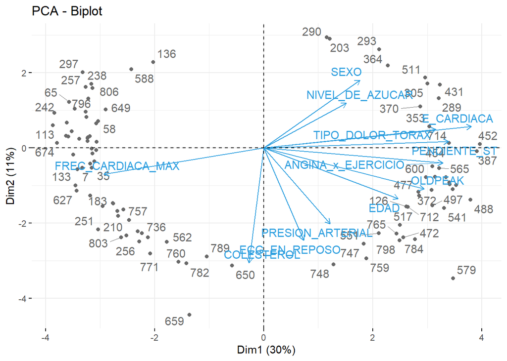

```r
#Representación de variables y los 100 individuos más influyentes en la misma gráfica
fviz_pca_biplot(pca, repel = TRUE, col.var = "#2E9FDF",
                col.ind = "#696969", select.ind = list(contrib = 100))
```

Al mostrar solamente los casos mas influyentes, se puede ver con mas claridad las relaciones entre los individuos y las características. Podemos concluir de este análisis de componentes, que no se puede quitar ninguna característica ya que se perdería información.

## 2.7 Comprobación de la normalidad y la homogeneidad de la varianza variables numericas

Para la comprobación de que los valores que toman nuestra variables cuantativa provienen de una distirbución normal vamos a utilizar la prueba de normalidad de Anderson-Darling.

```r
if (!require('nortest')) install.packages('nortest'); library('nortest')
alpha = 0.05
col.names = colnames(datos_final)
ind = 1

# Comprobanos unicamente lS variables que inicialmente eran de tipo numericas

for (i in colnames(datos_final)) {
  if (ind == 1) cat("Variables que no siguen una distribución normal:\n")
  if(vector_tipos[ind] == "numeric")
  {
    p_val = ad.test(unlist(datos_final[i]))$p.value
    if (p_val < alpha) {
      cat(i)
      # Format output
        if (ind < ncol(datos) - 1) cat(", ")
        if (ind %% 3 == 0) cat("\n")
      }
  }
  ind = ind + 1
  }
```

```
## Variables que no siguen una distribución normal:
## EDAD, PRESION_ARTERIAL, COLESTEROL, NIVEL_DE_AZUCAR,
## FREC_CARDIACA_MAX, OLDPEAK, E_CARDIACA
```

Podemos realizar un Q-Q plot para comprobar si las variables obtenidas en el anterior punto no siguen una distribución normal.

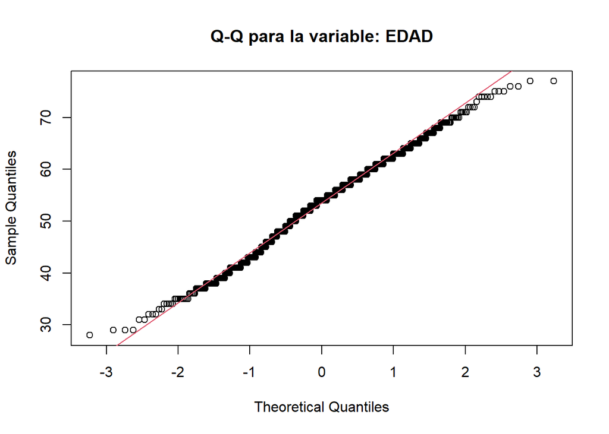

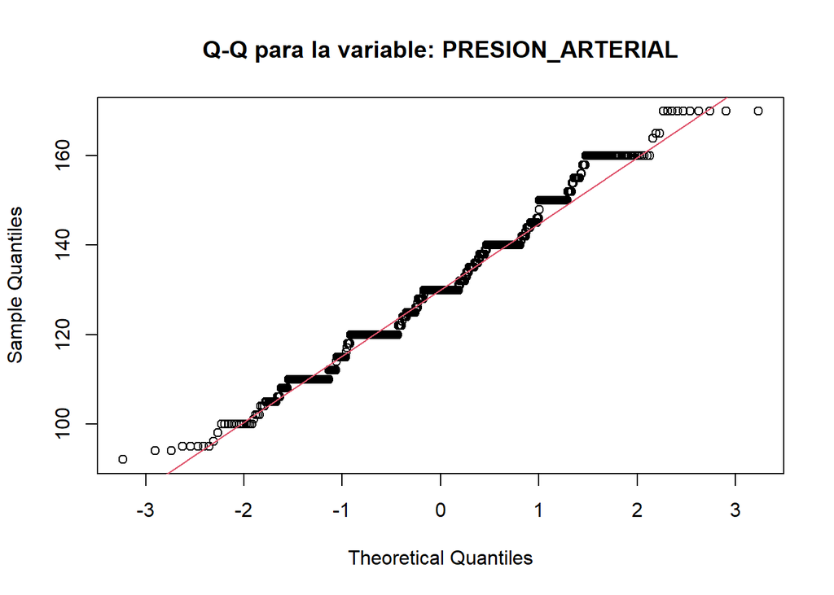

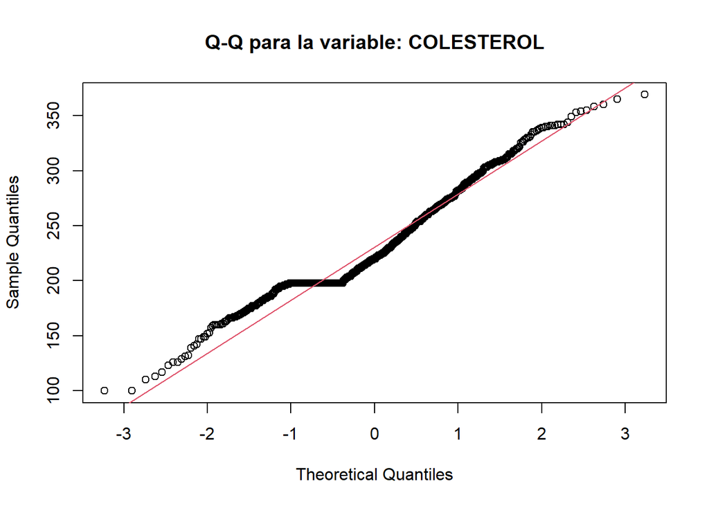

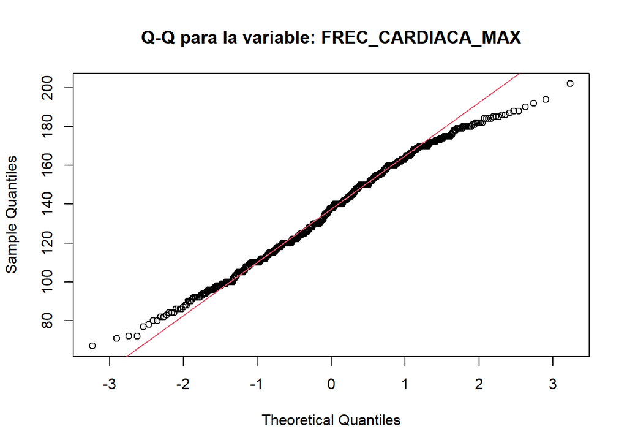

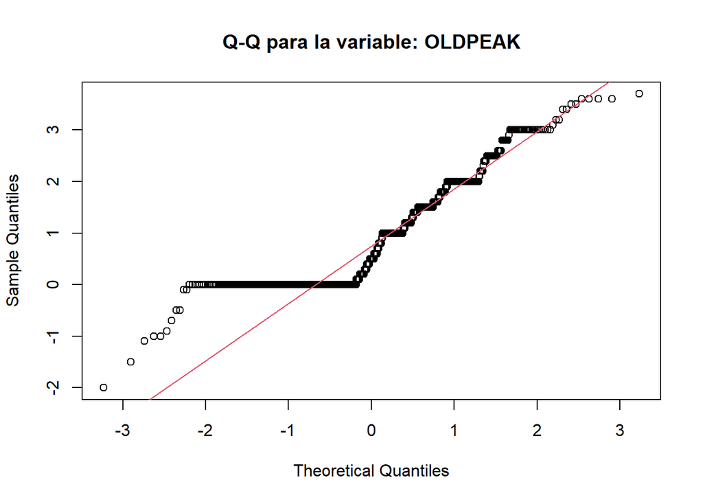

```r
variables <- c("EDAD", "PRESION_ARTERIAL", "COLESTEROL",
               "FREC_CARDIACA_MAX", "OLDPEAK")


for(i in(variables))
{
  qqnorm(unlist(datos_final[i]),  main = paste0("Q-Q para la variable: ", i));qqline(unlist(datos_final[i]), col = 2)
}
```

Vemos que tanto la distribución de los valores de las caracteristicas de EDAD y de la Frecuencia Cardica máxima se acercan mucho a la normalidad, por otro lado la distribución de los valores de la caracteristica Presión Arterial, Colesterol y Old distan de la normal.

# 3 Exportación de los datos

Una vez que hemos acometido sobre el conjunto de datos inicial los procedimientos de integración, validación y limpieza anteriores, procedemos a guardar estos en un nuevo fichero denominado heart_dissease_data_clean.csv:

```r
# Exportación de los datos limpios en .csv
write.csv(datos_final, "./heart_dissease_data_clean.csv")
```

# 4 Análisis de los datos

## 4.1 ¿Cuáles son los factores o parámetros que más influyen a la hora de tener una enfermedad cardiaca? (Correlaciones y Regresión logística)

### 4.1.1 Test de Spearman

```r
corr_matrix <- matrix(nc=2, nr=0)
colnames(corr_matrix) <- c("estimate", "p-value")

# Calculamos el coficiente de correlacion para cada variable cuantitativa
# con respecto al campo E. CARDICA

for(i in 1:(ncol(datos_final) -1 ))
{
  if(vector_tipos[i] == "numeric")
  {
    spearman_test = cor.test(unlist(datos_final[,i]),
                              unlist(datos_final[,length(datos_final)]),
                              method = "spearman")
    corr_coef <- spearman_test$estimate
    p_val <- spearman_test$p.value

    # Aañade a la matriz
    pair <- matrix(ncol = 2, nrow = 1)
    pair[1][1] = corr_coef
    pair[2][1] = p_val
    corr_matrix <- rbind(corr_matrix, pair)
    rownames(corr_matrix)[nrow(corr_matrix)] <- colnames(datos_final)[i]
  }

}

print(corr_matrix)
```

```
##                      estimate      p-value
## EDAD               0.32133836 5.839139e-21
## PRESION_ARTERIAL   0.11079517 1.566612e-03
## COLESTEROL        -0.06760546 5.414249e-02
## NIVEL_DE_AZUCAR    0.28341365 1.825875e-16
## FREC_CARDIACA_MAX -0.42471804 6.745047e-37
## OLDPEAK            0.44538146 8.078414e-41
```

Podemos identificar cual es la variable más correlacionada con la variable Enfermedad Cardiaca, viendo cuales de los valores de la columan estimate se acercan más al valor +1 o -1, en este caso los más cercanos y por lo tanto los que más correlacionados están con la varibale objetivo son: OLDPEAK y FREC CARDÍACA MAX.

### 4.1.2 Regresión logística

#### 4.1.2.1 Generación de los conjuntos de entrenamiento y de test

```r
set.seed(123)
ind <- sample(seq_len(nrow(datos_final)), size = round(.8 * dim(datos_final)[1]))
training <- datos_final[ind, ]
testing <- datos_final[-ind, ]
prop.table(table(datos_final$E_CARDIACA))
```

```
##
##         0         1
## 0.4507389 0.5492611
```

```r
prop.table(table(training$E_CARDIACA))
```

```
##
##         0         1
## 0.4569231 0.5430769
```

```r
prop.table(table(testing$E_CARDIACA))
```

```
##
##         0         1
## 0.4259259 0.5740741
```

#### 4.1.2.2 Estimación del modelo con el conjunto de entrenamiento e interpretación

```r
#Estimación del modelo
mod1<- glm(E_CARDIACA~.,data=training[,-1], family=binomial)
summary(mod1)
```

```
##
## Call:
## glm(formula = E_CARDIACA ~ ., family = binomial, data = training[,
##     -1])
##
## Deviance Residuals:
##     Min       1Q   Median       3Q      Max
## -3.5113  -0.4332   0.1592   0.4636   2.4653
##
## Coefficients:
##                      Estimate Std. Error z value Pr(>|z|)
## (Intercept)        -3.7391233  1.6052230  -2.329 0.019841 *
## SEXO                1.3672239  0.3170565   4.312 1.62e-05 ***
## TIPO_DOLOR_TORAX    1.0365159  0.1755062   5.906 3.51e-09 ***
## PRESION_ARTERIAL    0.0010092  0.0081799   0.123 0.901809
## COLESTEROL          0.0001034  0.0027892   0.037 0.970441
## NIVEL_DE_AZUCAR     1.4315653  0.3213654   4.455 8.40e-06 ***
## ECG_EN_REPOSO       0.1695613  0.1510045   1.123 0.261484
## FREC_CARDIACA_MAX  -0.0132493  0.0053744  -2.465 0.013691 *
## ANGINA_x_EJERCICIO  0.9887369  0.2889107   3.422 0.000621 ***
## OLDPEAK             0.3031768  0.1508919   2.009 0.044513 *
## PENDIENTE_ST        1.8443446  0.2498882   7.381 1.57e-13 ***
## ---
## Signif. codes:  0 '***' 0.001 '**' 0.01 '*' 0.05 '.' 0.1 ' ' 1
##
## (Dispersion parameter for binomial family taken to be 1)
##
##     Null deviance: 896.26  on 649  degrees of freedom
## Residual deviance: 442.58  on 639  degrees of freedom
## AIC: 464.58
##
## Number of Fisher Scoring iterations: 5
```

Existe colinealidad en todas la variables menos en: FREC_CARDIACA_MAX, ANGINA_x_EJERCICIO, OLDPEAK y PENDIENTE_ST

```r
training2 = training %>%
select(-SEXO,-TIPO_DOLOR_TORAX, -PRESION_ARTERIAL, -COLESTEROL, -NIVEL_DE_AZUCAR, -ECG_EN_REPOSO)
ModlgF<- glm(E_CARDIACA~.,data=training2, family=binomial)
summary(ModlgF)
```

```
##
## Call:
## glm(formula = E_CARDIACA ~ ., family = binomial, data = training2)
##
## Deviance Residuals:
##     Min       1Q   Median       3Q      Max
## -3.2307  -0.5666   0.2488   0.5422   2.2897
##
## Coefficients:
##                     Estimate Std. Error z value Pr(>|z|)
## (Intercept)        -0.788651   1.161330  -0.679 0.497079
## EDAD                0.029939   0.013153   2.276 0.022831 *
## FREC_CARDIACA_MAX  -0.017371   0.005019  -3.461 0.000538 ***
## ANGINA_x_EJERCICIO  1.242050   0.254904   4.873  1.1e-06 ***
## OLDPEAK             0.351152   0.140126   2.506 0.012212 *
## PENDIENTE_ST        1.878777   0.219396   8.563  < 2e-16 ***
## ---
## Signif. codes:  0 '***' 0.001 '**' 0.01 '*' 0.05 '.' 0.1 ' ' 1
##
## (Dispersion parameter for binomial family taken to be 1)
##
##     Null deviance: 896.26  on 649  degrees of freedom
## Residual deviance: 533.76  on 644  degrees of freedom
## AIC: 545.76
##
## Number of Fisher Scoring iterations: 5
```

Se observa que todas las variables explicativas son significativas con un nivel de significación del 5%

#### 4.1.2.3 Predicciones con con casos del dataframe

```r
pred_1 <-predict (ModlgF, datos_final[1,], type = "response")
cat("La probabilidad de que el primer usuario tenga una enfermedad cardiaca es del: ", pred_1*100)
```

```
## La probabilidad de que el primer usuario tenga una enfermedad cardiaca es del:  7.051109
```

```r
pred_14 <-predict (ModlgF, datos_final[14,], type = "response")
cat("La probabilidad de que el usuario 14 tenga una enfermedad cardiaca es del: ", pred_14*100)
```

```
## La probabilidad de que el usuario 14 tenga una enfermedad cardiaca es del:  84.79263
```

Nos damos cuenta de que la probabilidad obtenida es muy acertada a si esos usuarios han tenido o no enfermedad cardiaca.

## 4.2 ¿Influye el sexo en tener una enfermedad cardiaca? (Contraste de hipótesis)

### 4.2.1 Hipótesis nula y la alternativa

H0 : Enf.Cardiaca_Mujer = Enf.Cardiaca_Hombre

H1 : Enf.Cardiaca_Mujer != Enf.Cardiaca_Hombre

### 4.2.2 Preparación datos

```r
hombres <- datos_final[datos_final$SEXO==1,]
mujeres <- datos_final[datos_final$SEXO==0,]

var.test( as.numeric(hombres$E_CARDIACA),  as.numeric(mujeres$E_CARDIACA) )
```

```
##
##  F test to compare two variances
##
## data:  as.numeric(hombres$E_CARDIACA) and as.numeric(mujeres$E_CARDIACA)
## F = 1.2869, num df = 646, denom df = 164, p-value = 0.04968
## alternative hypothesis: true ratio of variances is not equal to 1
## 95 percent confidence interval:
##  1.000355 1.626469
## sample estimates:
## ratio of variances
##           1.286949
```

### 4.2.3 Cálculo

```r
t.test( as.numeric(datos_final$SEXO), as.numeric(datos_final$E_CARDIACA), alternative="greater", conf.level=0.95)
```

```
##
##  Welch Two Sample t-test
##
## data:  as.numeric(datos_final$SEXO) and as.numeric(datos_final$E_CARDIACA)
## t = 11.016, df = 1554, p-value < 2.2e-16
## alternative hypothesis: true difference in means is greater than 0
## 95 percent confidence interval:
##  0.2105546       Inf
## sample estimates:
## mean of x mean of y
## 0.7967980 0.5492611
```

## 4.3 Modelo Arbol de Decision

Podemos elaborar un arbol de decisión, para ver que variables tienen más influencia en la enfermedad cardiaca y establecer las reglas que definen dicha variable.

### 4.3.1 Test estadísticos de significancia

Antes de proceder a la clasificación de los parámetros de pacientes con más probabilidades de sufrir enfermedad cardiaca, deberemos de hacer una selección previa de las caracteristicas a utilizar en nuestro modelo.

Para aplicar los modelos de arbol de decision debemos de discretizar las variables COLESTEROL y FREC CARDIACA MAXIMA.

```r
# Backup dataset inicial:
datos_final_orig <- datos_final

datos_final <- datos_final %>% mutate(COLESTEROL = case_when(
  COLESTEROL < 100 ~ 0,
  (COLESTEROL >= 100 & COLESTEROL < 200) ~ 1,
  (COLESTEROL >= 200 & COLESTEROL < 300) ~ 2,
  (COLESTEROL >= 300 & COLESTEROL < 400) ~ 3,
  (COLESTEROL >= 400 & COLESTEROL < 500) ~ 4,
  COLESTEROL >= 600 ~ 5,
  ))


datos_final <- datos_final %>% mutate(FREC_CARDIACA_MAX = case_when(
  FREC_CARDIACA_MAX < 50 ~ 0,
  (FREC_CARDIACA_MAX >= 50 & FREC_CARDIACA_MAX < 80) ~ 1,
  (FREC_CARDIACA_MAX >= 80 & FREC_CARDIACA_MAX < 110) ~ 2,
  (FREC_CARDIACA_MAX >= 110 & FREC_CARDIACA_MAX < 140) ~ 3,
  (FREC_CARDIACA_MAX >= 140 & FREC_CARDIACA_MAX < 170) ~ 4,
  (FREC_CARDIACA_MAX >= 170 & FREC_CARDIACA_MAX < 200) ~ 5,
  FREC_CARDIACA_MAX >= 200 ~ 6,
  ))


# Convertimos todas las variables a tipo factor
datos_final[] <- lapply(datos_final, factor)

# Vector de etiquetas
vector_etiquetas = list(
  c("1: Mujeres","2: Hombres"),
  c("1: ATA", "2: NAP", "3: ASY"),
  c("1: [0,100]","2: [100,200]", "3: [200,300]", "4: [300,400]", "5: [400,500]", "6: [500,600]", "7: >600"),
  c("1: Normal","2: ST", "3: LVH"),
  c("1: <50","2: [50,80]","3: [80,110]","4: [110,140]","5: [150,170]","6: [170,200]", "7: >200"),
  c("1: N", "2: S"),
  c("1: Asc", "2: Plano", "3: Desc")
)
```